# 03_lmmur_chapter3

Randy

9/5/2021

# Chapter 3 Data Exploration

## 3.2 ARMD Trial: Visual Acuity

mainly interested in the effect of treatment on the visual acuity measurements.

looking at the measurements by plotting them against time for several selected patients from both treatment groups.

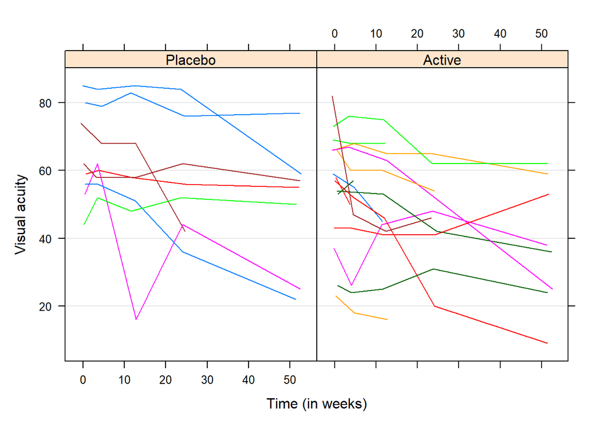

```r
data(armd.wide, armd0, package = "nlmeU")
library(lattice)
# View(armd0)
# View(armd.wide)

# Subset
armd0.subset <- armd0 %>%
  filter(subject %in% seq(1, 240, 10))

# View(armd0.subset)
# subset(armd0, as.numeric(subject) %in% seq(1, 240, 10))

# Draft plot
xy1 <-
  lattice::xyplot(
    ##  The function jitter()
    ##  is used to add a small amount of
    ##  noise to the variable time,
    ##  thereby reducing overlapping points.
    visual ~ jitter(time) | treat.f,
    groups = subject,
    data = armd0.subset,
    type = "l",
    lty = 1
    )

# Fig. 3.1
update(
  xy1,
  xlab = "Time (in weeks)",
  ylab = "Visual acuity",
  grid = "h"
  )
```

```r
detach(package:lattice)
```

- In general, visual acuity **tends to decrease in time**. This is in agreement with the remark that patients with ARMD progressively lose vision.
- For some patients, a **linear decrease** of visual acuity over time can be observed, but there are also patients for whom individual profiles strongly **deviate from a linear trend**.
- Visual acuity measurements adjacent in time are fairly **well correlated**, with the correlation decreasing with an increasing distance in time.
- Visual acuity at **baseline** seems to, at least partially, determine the overall level of the post-randomization measurements.
- There are patients for whom several **measurements are missing**.

These observations will be taken into account when constructing models for the data.

- The formula used in the syntax indicates that the variables visual and time are to be used on the y- and x-axis, respectively.
- These variables are plotted against each other in separate panels for different values of the factor.
- Within each panel, data points are grouped for each subject and connected using solid lines.
- The function `jitter()` is used to add a small amount of noise to the variable time, thereby reducing the number of overlapping points.

### 3.2.1 Patterns of Missing Data

```r
table(armd.wide$miss.pat)
```

```
##
## ---- ---X --X- --XX -XX- -XXX X--- X-XX XXXX
##  188   24    4    8    1    6    2    1    6
```

```r
with(armd.wide, table(miss.pat))
```

```
## miss.pat
## ---- ---X --X- --XX -XX- -XXX X--- X-XX XXXX
##  188   24    4    8    1    6    2    1    6
```

```r
## Create a contingency table
## (optionally a sparse matrix)
## from cross-classifying factors,
## usually contained in a data frame,
## using a formula interface.
xtabs(~miss.pat, armd.wide)
```

```
## miss.pat
## ---- ---X --X- --XX -XX- -XXX X--- X-XX XXXX
##  188   24    4    8    1    6    2    1    6
```

- From the displayed results, we can conclude that, for instance, there were 188 patients for whom all four postrandomization visual acuity measurements were obtained.
- On the other hand, there were six patients for whom the four measurements were missing.
- It is also worth noting that there are eight with four different nonmonotone missing-data patterns, i.e., with intermittent missing.
- When modeling data with such patterns, extra care is needed when specifying variance-covariance structures.

### 3.2.2 Mean-Value Profiles

```r
## (a) Counts of nonmissing visual acuity measurements
attach(armd0)

# "By" factors
flst <- list(time.f, treat.f)
## Counting
(tN <- tapply(visual, flst,
              FUN = function(x) length(x[!is.na(x)])
              ))
```

```
##          Placebo Active
## Baseline     119    121
## 4wks         117    114
## 12wks        117    110
## 24wks        112    102
## 52wks        105     90
```

```r
## (b) Sample means and medians of visual acuity measurements
# Sample means
tMn <- tapply(visual, flst, FUN = mean)
# Sample medians
tMd <- tapply(visual, flst, FUN = median)
# Column names
colnames(res <- cbind(tN, tMn, tMd))
```

```
## [1] "Placebo" "Active"  "Placebo" "Active"  "Placebo" "Active"
```

```r
nms1 <- rep(c("P", "A"), 3)
nms2 <- rep(c("n", "Mean", "Mdn"), rep(2, 3))
# New column names
colnames(res) <- paste(nms1, nms2, sep = ":")
res
```

```
##          P:n A:n   P:Mean   A:Mean P:Mdn A:Mdn
## Baseline 119 121 55.33613 54.57851  56.0  57.0
## 4wks     117 114 53.96581 50.91228  54.0  52.0
## 12wks    117 110 52.87179 48.67273  53.0  49.5
## 24wks    112 102 49.33036 45.46078  50.5  45.0
## 52wks    105  90 44.43810 39.10000  44.0  37.0
```

```r
detach(armd0)
```

- There are more missing measurements in active treatment group.
- We conclude that, on average, there was very little difference in visual acuity between the two treatment groups at baseline, which is expected in a randomized study.
- During the course of the study, the mean visual acuity decreased with time in both arms, which confirms the observation made based on the individual profiles presented.
- It is worth noting that the mean value is consistently higher in the placebo group, which suggests lack of effect …

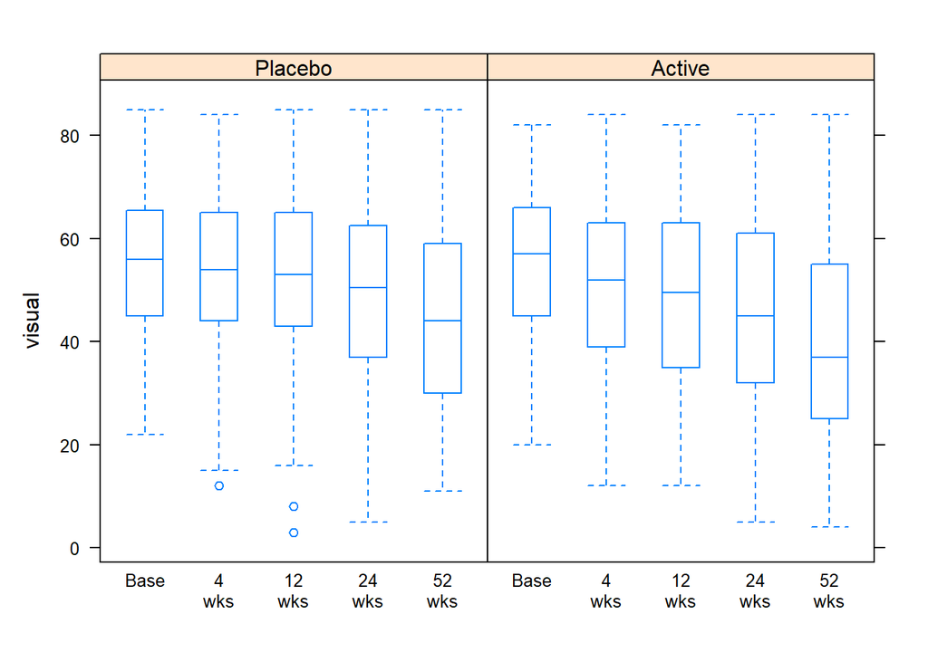

```r
## the function bwplot() from the package lattice
## A disadvantage of the plot is that
## it does not reflect the longitudinal
## structure of the data
library(lattice)
bw1 <- bwplot(visual ~ time.f | treat.f,
              data = armd0)

xlims <- c("Base", "4\nwks", "12\nwks",
           "24\nwks", "52\nwks")
update(bw1, xlim = xlims, pch = "|")
```

```r
detach(package:lattice)
```

```r
## (a) Subset of the data with monotone missing-data patterns
## use droplevels() function to remove the unused levels
mnt.pat <- # Monotone patterns
  c("----", "---X", "--XX", "-XXX", "XXXX")
armd.wide.mnt <- # Data subset
  subset(armd.wide,
         miss.pat %in% mnt.pat)
# Number of rows and cols
dim(armd.wide.mnt)
```

```
## [1] 232  10
```

```r
# View(armd.wide.mnt)

# Some levels not needed
levels(armd.wide.mnt$miss.pat)
```

```
## [1] "----" "---X" "--X-" "--XX" "-XX-" "-XXX" "X---" "X-XX" "XXXX"
```

```r
## (b) Removing unused levels from the miss.pat factor
armd.wide.mnt1 <-
  within(armd.wide.mnt, {
    miss.pat <- factor(miss.pat, levels = mnt.pat)
  })
levels(armd.wide.mnt1$miss.pat)
```

```
## [1] "----" "---X" "--XX" "-XXX" "XXXX"
```

```r
## (c) The number of patients with different monotone missing-data patterns
with(armd.wide.mnt1, {
  # List of "by" factors
  fl <- list(treat.f, miss.pat)
  tapply(subject, fl,
         FUN = function(x) length(x[!is.na(x)]))
})
```

```
##         ---- ---X --XX -XXX XXXX
## Placebo  102    9    3    1    1
## Active    86   15    5    5    5
```

- The displayed results indicate that the mean-value profiles for missing-data patterns with a larger number of missing values, are based on measurements for a small number of patients.
- Thus, the variability of these profiles is larger than for the patterns with a smaller number of missing values.
- Therefore, the interpretation of missing pattern figures should be applied with caution.

## 3.2.3 Sample Variances and Correlations of Visual Acuity Measurements

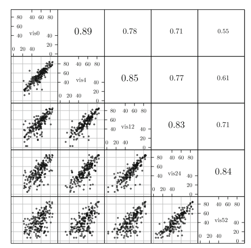

```r
knitr::include_graphics("figure/f3.4.png")
```

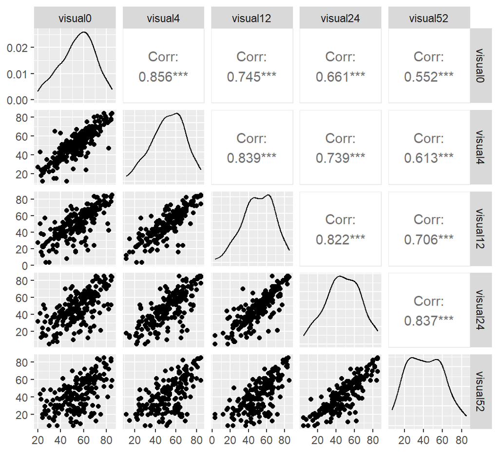

```r
## Quick display of two cabapilities of GGally,
## to assess the distribution and correlation of variables
# library(GGally)
#
## Create data
# data <- data.frame(
#   v1 = 1:100 rnorm(100, sd = 20),
#   v2 = 1:100 rnorm(100, sd = 27),
#   v3 = rep(1, 100) rnorm(100, sd = 1),
#   v4 = rep(1, 100) rnorm(100, sd = 20),
#   v5 = rep(1, 100) rnorm(100, sd = 27)
#   )
#
## Check correlations (as scatterplots), distribution and print corrleation coefficient
# ggpairs(data, title = "correlogram with ggpairs()")


armd.wide.mnt %>%
  select(visual0:visual52) %>%
  GGally::ggpairs()
```

- It can be observed that the measurements adjacent in time are strongly correlated.
- The correlation decreases with an increasing time gap.
- Worth noting is the fact that there is a substantial positive correlation between visual acuity at baseline and at the other post-randomization measurements.
- Thus, baseline values might be used to explain the overall variability of the post-randomization observations.
- This agrees with the observation made based on Fig. 3.1.
- It is worth noting that a scatterplot matrix of this type may not work well for longitudinal data with irregular time intervals.

```r
visual.x <- subset(armd.wide,
                   select = c(visual0:visual52))
# View(visual.x)

## Var-cov mtx
(varx <- var(visual.x,
             ## selects only those rows of
             ## the data frame visual.x
             ## do not contain any missing values.
             ## An alternative would be to specify
             ## use = "pairwise.complete.obs"
             ## In that case, the elements of the matrices
             ## would be estimated using data
             ## for all patients with complete observations
             ## for the particular paired measurements.
             ## This could result in estimates
             ## of var-cov not be PSD
             use = "complete.obs"))
```

```
##           visual0  visual4 visual12 visual24 visual52
## visual0  220.3055 206.7096 196.2439 193.3099 152.7141
## visual4  206.7096 246.2204 224.7933 221.2677 179.2284
## visual12 196.2439 224.7933 286.2072 257.7738 222.6830
## visual24 193.3099 221.2677 257.7738 334.4456 285.2327
## visual52 152.7141 179.2284 222.6830 285.2327 347.4311
```

```r
## Corr mtx
print(
  cor(visual.x,
          ## selects only those rows of
          ## the data frame visual.x
          ## do not contain any missing values.
          use = "complete.obs"
      ),
      digits = 2)
```

```
##          visual0 visual4 visual12 visual24 visual52
## visual0     1.00    0.89     0.78     0.71     0.55
## visual4     0.89    1.00     0.85     0.77     0.61
## visual12    0.78    0.85     1.00     0.83     0.71
## visual24    0.71    0.77     0.83     1.00     0.84
## visual52    0.55    0.61     0.71     0.84     1.00
```

```r
## Var-cov diagonal elements
diag(varx)
```

```
##  visual0  visual4 visual12 visual24 visual52
## 220.3055 246.2204 286.2072 334.4456 347.4311
```

```r
## Corr mtx (alternative way)
cov2cor(varx)
```

```
##            visual0   visual4  visual12  visual24  visual52
## visual0  1.0000000 0.8875360 0.7815256 0.7121620 0.5519911
## visual4  0.8875360 1.0000000 0.8468003 0.7710692 0.6127882
## visual12 0.7815256 0.8468003 1.0000000 0.8331742 0.7061752
## visual24 0.7121620 0.7710692 0.8331742 1.0000000 0.8367625
## visual52 0.5519911 0.6127882 0.7061752 0.8367625 1.0000000
```

- Toward this end, we create the data frame visual.x from armd.wide by selecting only the five variables containing the measurements.
- We then apply functions `var()` and `cor()` to estimate the variance–covariance matrix and the correlation matrix, respectively.
- In this way, the estimated matrices are assured to be positive semidefinite.
- It indicates an increase of the variance of visual acuity measurements obtained at later timepoints.
- The estimated correlation matrix suggests a moderate to strong correlation of the measurements.
- The correlation clearly decreases with the time gap.

## 3.3 PRT Study: Muscle Fiber Specific Force

- In the PRT study, we are primarily interested in the effect of the intensity of the training on the muscle fiber specific force, measurements of which are contained in the variable `spec.fo` of the `prt` data frame.
- In some analyses, we will also investigate the effect on the measurements of the isometric force, which are stored in the variable `iso.fo`.
- The displayed values of the statistics do not indicate any substantial differences in the distribution of BMI between subjects assigned to randomization groups.
- Given that the assignment was randomized, this result is anticipated.

```r
# Data loaded
data(prt.subjects, prt,
     package = "nlmeU")
# View(prt.subjects)
with(prt.subjects,
     tapply(bmi, prt.f, summary))
```

```
## $High
##    Min. 1st Qu.  Median    Mean 3rd Qu.    Max.
##   18.37   22.86   24.77   25.11   28.19   31.00
##
## $Low
##    Min. 1st Qu.  Median    Mean 3rd Qu.    Max.
##   18.95   23.05   24.84   24.70   26.27   32.29
```

```r
## Apply a Function to a Data Frame Split by Factors
## by(data, INDICES, FUN, ..., simplify = TRUE)
by(subset(prt.subjects,
          select = -id),
   prt.subjects$prt.f,
   summary)
```

```
## prt.subjects$prt.f: High
##   prt.f      age.f       sex.f         bmi
##  High:31   Young:15   Female:17   Min.   :18.37
##  Low : 0   Old  :16   Male  :14   1st Qu.:22.86
##                                   Median :24.77
##                                   Mean   :25.11
##                                   3rd Qu.:28.19
##                                   Max.   :31.00
## ------------------------------------------------------------
## prt.subjects$prt.f: Low
##   prt.f      age.f       sex.f         bmi
##  High: 0   Young:15   Female:17   Min.   :18.95
##  Low :32   Old  :17   Male  :15   1st Qu.:23.05
##                                   Median :24.84
##                                   Mean   :24.70
##                                   3rd Qu.:26.27
##                                   Max.   :32.29
```

```r
# prt.subjects %>%
#   group_by(prt.f) %>%
#   summarise(bmi_mean = mean(bmi),
#             quantile(bmi, probs = seq(0, 1, 0.25)))
```

```r
## This method uses purrr::map and a Function Operator,
## purrr::partial, to create a list of functions
## that can than be applied to a data set
## using dplyr::summarize_at and a little magic from rlang.
## Looking at p_funs we can see that we have a named list
## with each element containing a function
## comprised of the quantile function.
##
## The beauty of this is that you can use this list
## in the same way you would define multiple functions
## in any other summarize_at or summarize_all functions
## (i.e. funs(mean, sd)).
## now have to use ##  the “bang-bang-bang” operator (!!!)
## from rlang (it is also exported from dplyr).

p <- c(0.2, 0.5, 0.8)
p_names <- map_chr(p, ~paste0(.x * 100, "%"))
p_funs <-
  map(p,
      ~partial(quantile,
               probs = .x,
               na.rm = TRUE)) %>%
       set_names(nm = p_names)

p_funs

mtcars %>%
  group_by(cyl) %>%
  summarize_at(vars(mpg), funs(!!!p_funs))

mtcars %>%
  group_by(cyl) %>%
  summarize_at(vars(mpg, hp), funs(!!!p_funs)) %>%
  ## to re-arrange the order of the columns
  select(cyl, contains("mpg"), contains("hp"))
```

- From the displayed values of the statistics, we conclude that there are no important differences in the distribution of sex and age groups between the two intervention groups.
- This is expected, given that the randomization was stratified by the two factors.

```r
## (a) Number of fibers per type and occasion
## for the subjects "5" and "335"
fibL <-  with(prt,
              tapply(spec.fo,
                     list(id = id,
                          fiberF = fiber.f,
                          occF = occ.f),
                     length))
# View(prt)
# str(fibL)
dimnms <- dimnames(fibL)
# Shortened names displayed
names(dimnms)
```

```
## [1] "id"     "fiberF" "occF"
```

```r
# Number of fiber measurements for subject 5
fibL["5", , ]
```

```
##         occF
## fiberF   Pre Pos
##   Type 1  12  18
##   Type 2   7   4
```

```r
# Number of fiber measurements for subject 335
fibL["335", , ]
```

```
##         occF
## fiberF   Pre Pos
##   Type 1  NA   8
##   Type 2  14  11
```

```r
## (b) Mean value of spec.fo by fiber type
## and occasion for subject "5"
fibM <-
  with(prt,
       ## in the call to the function tapply(),
       ## we use a named list of the factors.
       ## names of the components of the list
       ## are shortened versions of the factor names.
    tapply(spec.fo,
           list(id = id,
                fiberF = fiber.f,
                occF = occ.f),
           mean))
fibM["5", , ]
```

```
##         occF
## fiberF        Pre      Pos
##   Type 1 132.5917 129.9556
##   Type 2 145.7429 147.9500
```

```r
## (a) Preprocessing of the data (melting)
library(reshape)
idvar <- c("id", "prt.f", "fiber.f", "occ.f")
meas.var <- c("spec.fo", "iso.fo")

# Melting data
prtM <- melt(prt,
             id.var = idvar,
             measure.var = meas.var)
## results from the stacking of the values of
## spec.fo and iso.fo in the variable value.
dim(prtM)
```

```
## [1] 4942    6
```

```r
names(prtM)
```

```
## [1] "id"       "prt.f"    "fiber.f"  "occ.f"    "variable" "value"
```

```r
## (b) Aggregating data (casting)
## Casting data
## Cast a molten data frame into the reshaped
## or aggregated form you want
## cast(data, formula = ... ~ variable, fun.aggregate=NULL, ...)
prtC <- cast(prtM,
             fun.aggregate = mean)
dim(prtC)
```

```
## [1] 249   6
```

```r
names(prtC)
```

```
## [1] "id"      "prt.f"   "fiber.f" "occ.f"   "spec.fo" "iso.fo"
```

```r
head(prtC, n = 8)
```

```
##   id prt.f fiber.f occ.f  spec.fo    iso.fo
## 1  5   Low  Type 1   Pre 132.5917 0.5150000
## 2  5   Low  Type 1   Pos 129.9556 0.7228889
## 3  5   Low  Type 2   Pre 145.7429 0.4705714
## 4  5   Low  Type 2   Pos 147.9500 0.7117500
## 5 10  High  Type 1   Pre 140.5625 0.7237500
## 6 10  High  Type 1   Pos 167.6429 0.7795714
## 7 10  High  Type 2   Pre 153.1667 0.7678333
## 8 10  High  Type 2   Pos 181.5643 0.6817857
```

```r
# Names modified
names(prtC)[5:6] <- c("spec.foMn", "iso.foMn")
# View(prtC)
# View(prtM)
```

- There is no clear effect of the training intensity
- In general, measurements of the specific force are higher for type-2 than for type-1 fibers
- On average, post-training values are larger than pre-training measurements
- For both types of fibers, there is a considerable variability between subjects with respect to the overall level of measurements and with respect to the magnitude of the post-pre differences
- There is a correlation between the mean measurements observed for the same individual, as seen, e.g., from the similar pattern of measurements for both types.

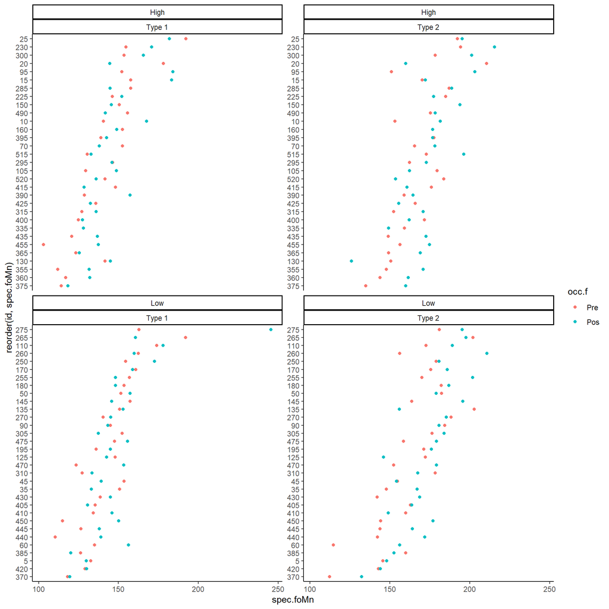

```r
f3.5 <- prtC %>%
  ggplot(aes(spec.foMn, reorder(id, spec.foMn), colour = occ.f)) +
  geom_point() +
  facet_wrap(. ~ prt.f + fiber.f, scales = "free_y")
  # facet_grid(prt.f + fiber.f~., scales = "free_y")
f3.5 + theme_classic()
```

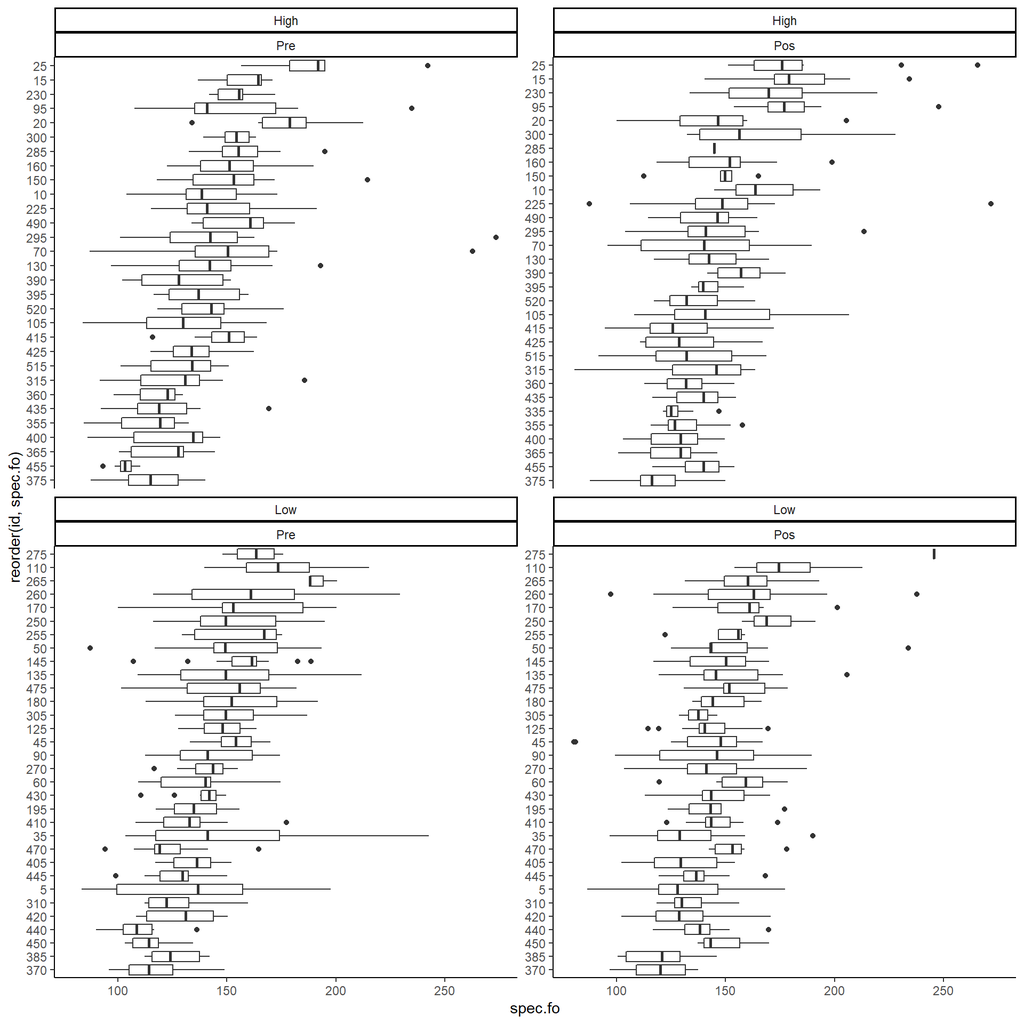

```r
f3.6 <- prt %>%
  filter(fiber.f == "Type 1") %>%
  ggplot(aes(spec.fo, y = reorder(id, spec.fo), group = id)) +
  geom_boxplot() +
  facet_wrap(. ~ prt.f + occ.f, scales = "free_y")
f3.6 + theme_classic()
```

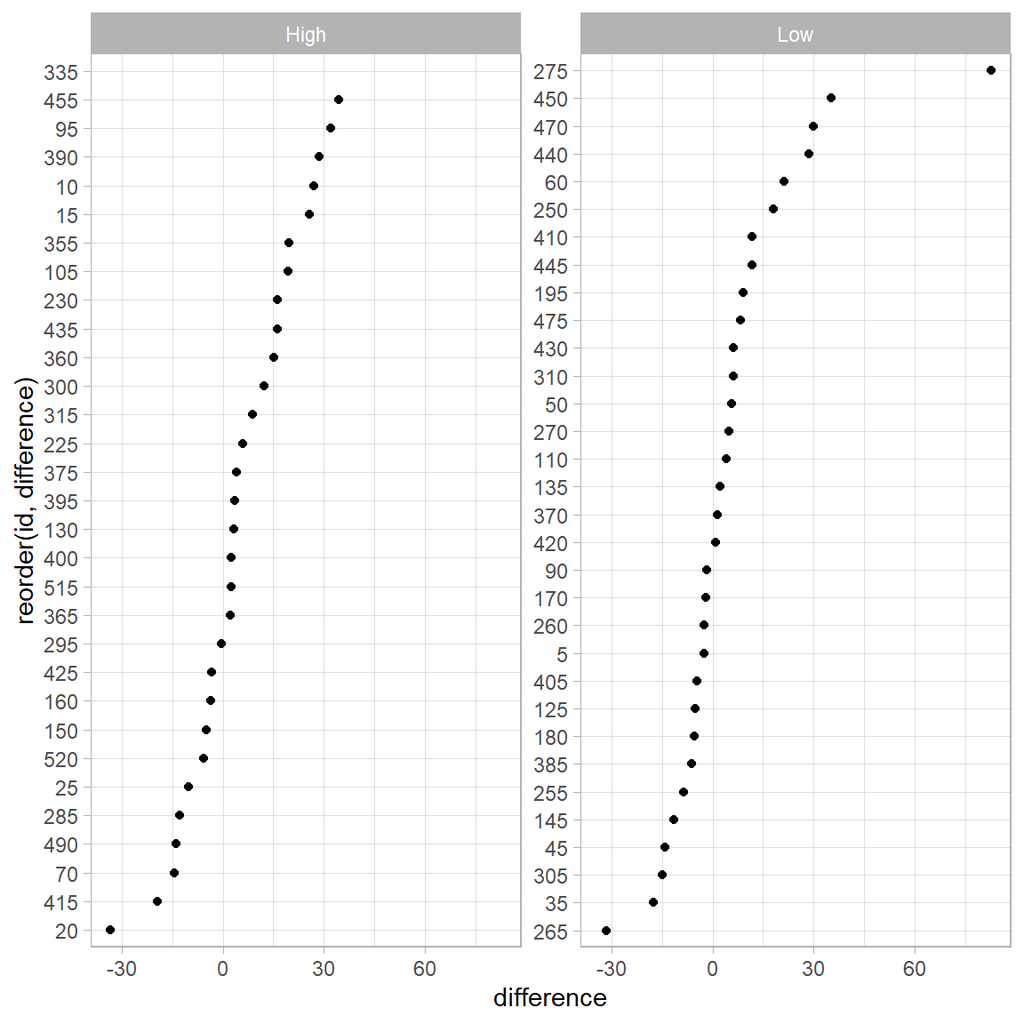

```r
f3.7 <- prtC %>%
  filter(fiber.f == "Type 1") %>%
  select(-iso.foMn) %>%
  pivot_wider(names_from = occ.f,
              values_from = spec.foMn) %>%
  mutate(difference = Pos - Pre) %>%
  ggplot(aes(difference, y = reorder(id, difference), group = id)) +
  geom_point() +
  facet_wrap(. ~ prt.f, scales = "free_y") +
  scale_y_discrete(drop = TRUE)


f3.7 + theme_light()
```

## 3.4 SII Project: Gain in the Math Achievement Score

```r
data(SIIdata, package = "nlmeU")
sapply(SIIdata, FUN = function(x) any(is.na(x)))
```

```
##      sex minority mathkind mathgain      ses yearstea mathknow housepov
##    FALSE    FALSE    FALSE    FALSE    FALSE    FALSE     TRUE    FALSE
## mathprep  classid schoolid  childid
##    FALSE    FALSE    FALSE    FALSE
```

```r
sum(as.numeric(is.na(SIIdata$mathknow)))
```

```
## [1] 109
```

```r
range(SIIdata$mathknow, na.rm = TRUE)
```

```
## [1] -2.50  2.61
```

### 3.4.1 School-Level Data

```r
(schlN <- xtabs(~schoolid, SIIdata))
```

```
## schoolid
##   1   2   3   4   5   6   7   8   9  10  11  12  13  14  15  16  17  18  19  20
##  11  10  14   6   6  12  14  16   6  18  31  27   9  15  13   6   9   4  11  12
##  21  22  23  24  25  26  27  28  29  30  31  32  33  34  35  36  37  38  39  40
##  17   4   5   8   7  15  21  10   8   3  22   9  22   7  11   8  11   9  12   7
##  41  42  43  44  45  46  47  48  49  50  51  52  53  54  55  56  57  58  59  60
##   9  18   4  17   5  13  10   6   8  12   4   9   8  10  13  10   8   5   4  13
##  61  62  63  64  65  66  67  68  69  70  71  72  73  74  75  76  77  78  79  80
##  11  13   3  10   9   8  12  16   5  19  27  11  10   3  15  27  24  15  12   7
##  81  82  83  84  85  86  87  88  89  90  91  92  93  94  95  96  97  98  99 100
##   9  19  12  14  20   7  10   6   4   3  16   9  21  15   5   8   6   2  19  13
## 101 102 103 104 105 106 107
##  16  11   8   6  10   2  10
```

```r
range(schlN)
```

```
## [1]  2 31
```

```r
xtabs(~schlN)
```

```
## schlN
##  2  3  4  5  6  7  8  9 10 11 12 13 14 15 16 17 18 19 20 21 22 24 27 31
##  2  4  6  5  8  5  9  9 10  7  7  6  3  5  4  2  2  3  1  2  2  1  3  1
```

```r
attach(SIIdata)
##  Toward this end, with the
##  help of the function by(),
##  we apply the function colMeans()
##  to the values of the two variables
##  within the groups defined by
##  the same level of the factor schoolid
(mthgM <- by(cbind(mathgain, mathkind), schoolid, colMeans))
```

```
## INDICES: 1
##  mathgain  mathkind
##  59.63636 458.36364
## ------------------------------------------------------------
## INDICES: 2
## mathgain mathkind
##     65.0    487.9
## ------------------------------------------------------------
## INDICES: 3
##  mathgain  mathkind
##  88.85714 469.14286
## ------------------------------------------------------------
## INDICES: 4
##  mathgain  mathkind
##  35.16667 462.66667
## ------------------------------------------------------------
## INDICES: 5
##  mathgain  mathkind
##  60.16667 445.33333
## ------------------------------------------------------------
## INDICES: 6
##  mathgain  mathkind
##  78.66667 457.08333
## ------------------------------------------------------------
## INDICES: 7
##  mathgain  mathkind
##  57.35714 442.07143
## ------------------------------------------------------------
## INDICES: 8
## mathgain mathkind
##  47.2500 498.6875
## ------------------------------------------------------------
## INDICES: 9
##  mathgain  mathkind
##  34.83333 475.33333
## ------------------------------------------------------------
## INDICES: 10
##  mathgain  mathkind
##  74.94444 441.33333
## ------------------------------------------------------------
```

[output cut: 372 more lines]

```
## INDICES: 104
##  mathgain  mathkind
##  87.66667 444.33333
## ------------------------------------------------------------
## INDICES: 105
## mathgain mathkind
##     61.4    460.0
## ------------------------------------------------------------
## INDICES: 106
## mathgain mathkind
##      9.5    526.5
## ------------------------------------------------------------
## INDICES: 107
## mathgain mathkind
##     48.2    464.2
```

```r
# View(mthgM)
View(SIIdata)
detach(SIIdata)
```

```r
## (a) Creating a data frame with the number
## of classes and children for each school
# library(reshape)
idvars <- c("schoolid")
mvars <- c("classid", "childid")
## into long format for the mean calculation
dtm1 <- melt(SIIdata,
             id.vars = idvars,
             measure.vars = mvars)
# View(dtm1)
names(cst1 <- cast(dtm1,
                   fun.aggregate = function(el)
                     length(unique(el))))
```

```
## [1] "schoolid" "classid"  "childid"
```

```r
# View(cst1)
names(cst1) <- c("schoolid", "clssn", "schlN")

## (b) Creating a data frame with
## the school-specific means of selected variables
mvars <- c("mathgain", "mathkind", "housepov")
dtm2 <- melt(SIIdata,
             id.vars = idvars,
             measure.vars = mvars)
names(cst2 <- cast(dtm2, fun.aggregate = mean))
```

```
## [1] "schoolid" "mathgain" "mathkind" "housepov"
```

```r
# View(cst2)
names(cst2) <- c("schoolid", "mthgMn", "mthkMn", "housepov")

## (c) Merging the data frames created in parts (a) and (b) above
(schlDt <- merge(cst1, cst2, sort = FALSE))
```

```
##     schoolid clssn schlN   mthgMn   mthkMn housepov
## 1          1     2    11 59.63636 458.3636    0.082
## 2          2     3    10 65.00000 487.9000    0.082
## 3          3     4    14 88.85714 469.1429    0.086
## 4          4     2     6 35.16667 462.6667    0.365
## 5          5     1     6 60.16667 445.3333    0.511
## 6          6     3    12 78.66667 457.0833    0.044
## 7          7     4    14 57.35714 442.0714    0.148
## 8          8     3    16 47.25000 498.6875    0.085
## 9          9     3     6 34.83333 475.3333    0.537
## 10        10     4    18 74.94444 441.3333    0.346
## 11        11     9    31 50.45161 499.8065    0.101
## 12        12     5    27 52.40741 462.5185    0.106
## 13        13     2     9 47.66667 479.4444    0.055
## 14        14     3    15 44.33333 468.9333    0.157
```

[output cut: 93 more lines]

```r
rm(cst1, cst2)
```

```r
## (a) Summary statistics for the
## school-specific mean values of housepov
summary(schlDt$housepov)
```

```
##    Min. 1st Qu.  Median    Mean 3rd Qu.    Max.
##  0.0120  0.0855  0.1480  0.1941  0.2645  0.5640
```

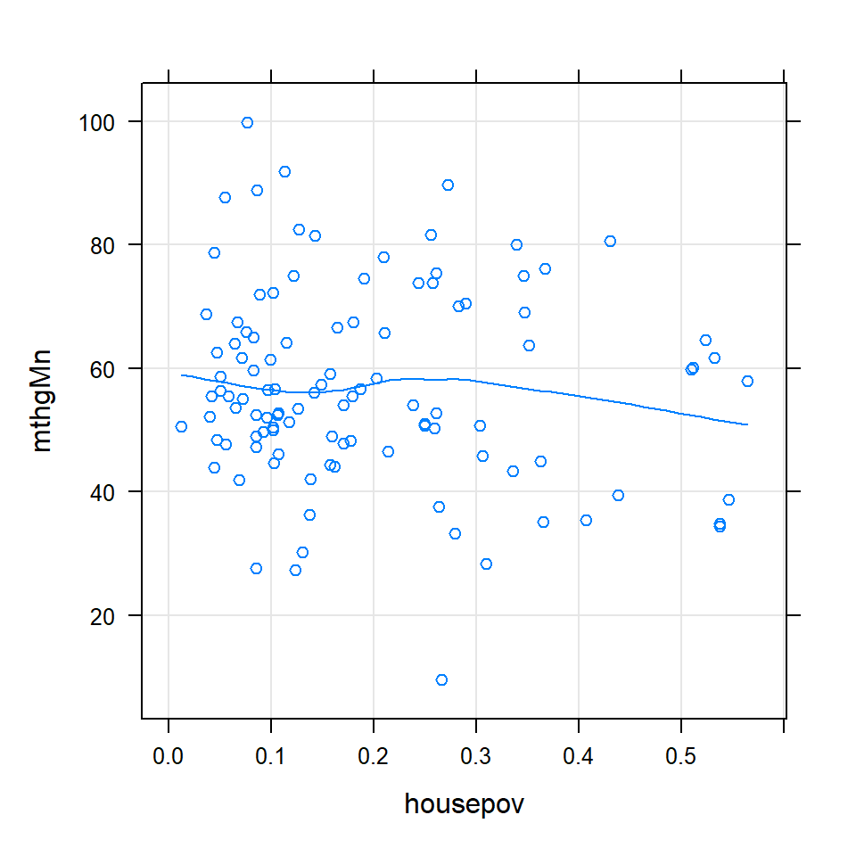

```r
# View(schlDt)

## (b) Scatterplots of the school-specific
## mean values for housepov and mathkind
library(lattice)
xyplot(mthgMn ~ housepov,
       schlDt,
       type = c("p", "smooth"),
       grid = TRUE)
```

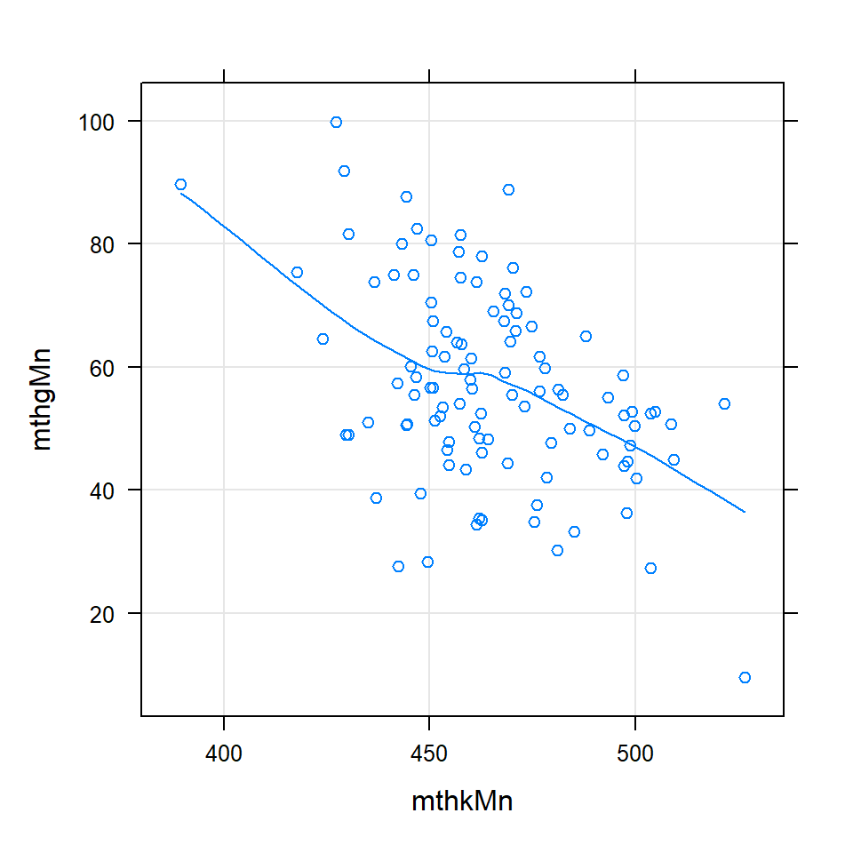

```r
xyplot(mthgMn ~ mthkMn,
       schlDt,
       type = c("p", "smooth"),
       grid = TRUE)
```

```r
# ?xyplot
```

- should be interpreted with caution, as they show school-specific means, which were estimated based on different numbers of observations.

### 3.4.2 Class-Level Data

```r
# (clssN <- xtabs(~ classid, SIIdata))
sum(clssN)
```

[output not shown]

```r
range(clssN)
```

[output not shown]

```r
(clssCnt <- xtabs(~clssN))
```

[output not shown]

```r
sum(clssCnt)
```

[output not shown]

```r
idvars <- c("classid", "housepov", "mathknow", "mathprep")
mvars <- c("childid")
## into long format for the mean calculation
dtm1 <- melt(SIIdata,
             id.vars = idvars,
             measure.vars = mvars)
# View(SIIdata)
# View(dtm1)
names(cst1 <- cast(dtm1,
                   fun.aggregate = function(el)
                     length(unique(el))))
```

```
## [1] "classid"  "housepov" "mathknow" "mathprep" "childid"
```

```r
# View(cst1)
names(cst1) <- c("class", "housepov",
                 "mathknow", "mathprep", "clssN")

## (b) Creating a data frame with
## the school-specific means of selected variables
mvars <- c("mathgain", "mathkind")
dtm2 <- melt(SIIdata,
             id.vars = idvars,
             measure.vars = mvars)
names(cst2 <- cast(dtm2, fun.aggregate = mean))
```

```
## [1] "classid"  "housepov" "mathknow" "mathprep" "mathgain" "mathkind"
```

```r
# View(cst2)
names(cst2) <- c("class", "housepov",
                 "mathknow", "mathprep",
                 "mthgMn", "mthkMn")
# View(cst2)
## (c) Merging the data frames created
## in parts (a) and (b) above
(clssDt <- merge(cst1, cst2, sort = FALSE))
```

```
##     class housepov mathknow mathprep clssN     mthgMn   mthkMn
## 1       1    0.335    -0.72     2.50     5  47.800000 459.0000
## 2       2    0.303     0.58     3.00     3  65.666667 454.0000
## 3       3    0.040     0.85     2.75     3  15.666667 492.6667
## 4       4    0.339     1.08     5.33     6  91.500000 437.0000
## 5       5    0.121     0.15     1.33     1 182.000000 342.0000
## 6       6    0.187    -0.12     3.75     5  39.400000 438.0000
## 7       7    0.261       NA     2.83     1  51.000000 429.0000
## 8       8    0.161     0.41     3.00     4  22.750000 484.5000
## 9       9    0.279    -1.09     1.50     3  -9.000000 483.0000
## 10     10    0.261    -1.26     3.25     2 106.000000 400.0000
## 11     11    0.086     0.45     3.83     4  85.000000 452.7500
## 12     12    0.101       NA     6.00     5  50.000000 484.0000
## 13     13    0.407     0.62     2.00     9  38.888889 468.5556
## 14     14    0.101     0.47     2.00     4  91.500000 451.2500
```

[output cut: 298 more lines]

```r
rm(cst1, cst2)
# View(clssDt)
```

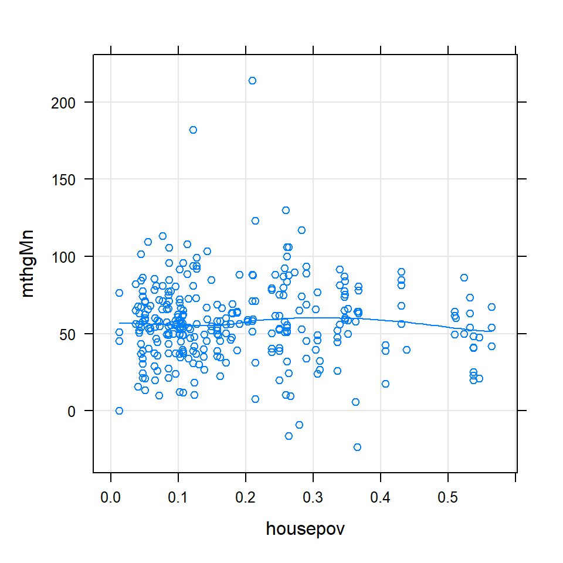

```r
library(lattice)
xyplot(mthgMn ~ housepov,
       clssDt,
       type = c("p", "smooth"),
       grid = TRUE)
```

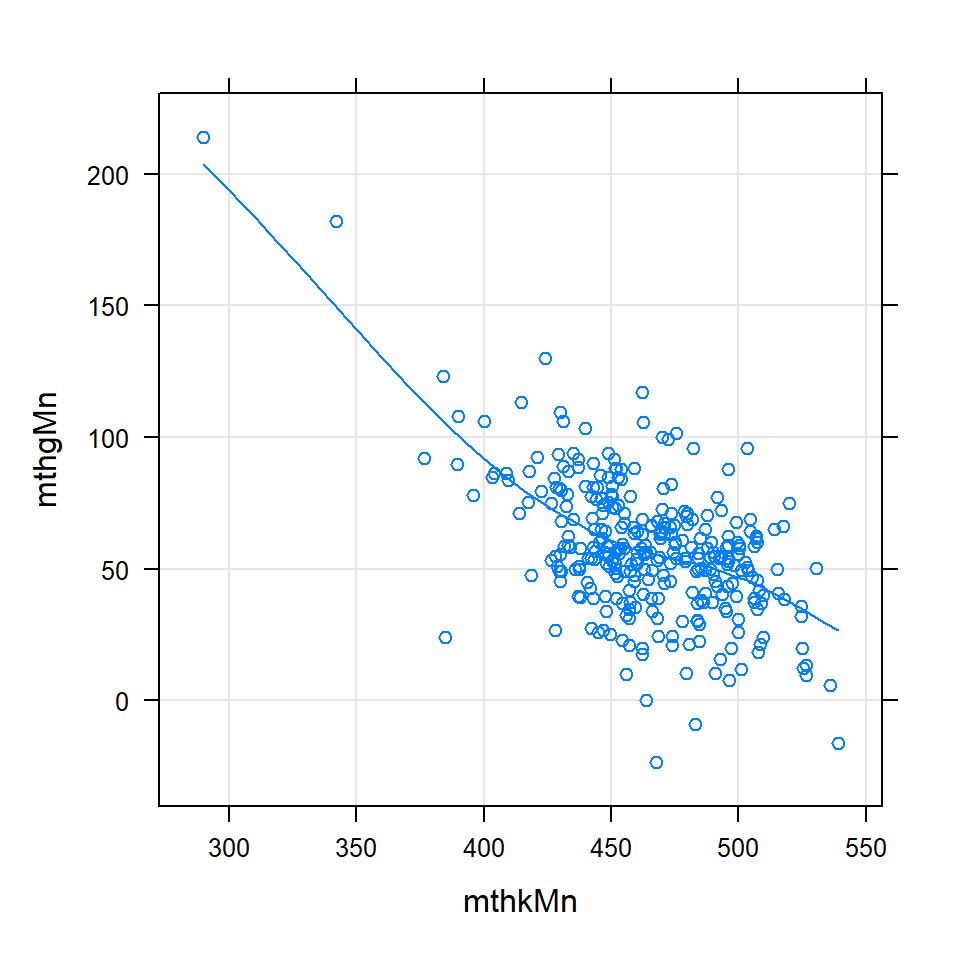

```r
xyplot(mthgMn ~ mthkMn,
       clssDt,
       type = c("p", "smooth"),
       grid = TRUE)
```

- Figure 3.9a does not suggest a strong relationship between the mean values of mathgain and housepov.
- On the other hand, as seen in Fig. 3.9b, there is a strong negative relationship between the mean values of mathgain and mathkind.
- These conclusions are similar to the ones drawn based on Fig. 3.8.
- As was the case for the latter figure, the plots in Fig. 3.9 should be interpreted with caution, as they show class-specific mean values estimated based on different numbers of observations.

### 3.4.3 Pupil-Level Data

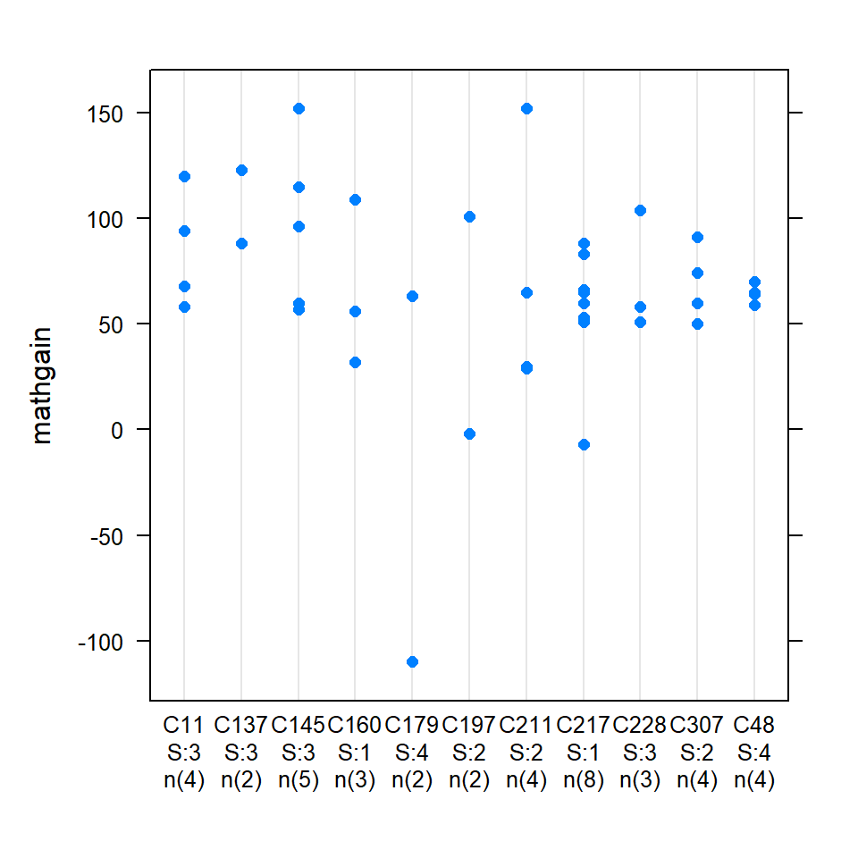

```r
## (a) Adding the class-level data to the data frame SIIdata
auxDt <- merge(SIIdata, clssDt, sort = FALSE)
# View(auxDt)
# auxDt2 <- within(auxDt,
#                  {
#                    auxL <- paste(classid, schoolid, sep = ":")
#                    auxL1 <- paste(auxL, clssN, sep = "(")
#                    auxL2 <- paste(auxL1, ")", sep = "")
#                    clssF <- factor(schoolid:classid,
#                                    labels = unique(auxL2))
#                    }
#                  )

auxDt2 <- auxDt %>%
  mutate(clssF = paste("C", classid, "\nS:", schoolid,
                       "\nn(", clssN, ")",sep = ""))
# View(auxDt2)
tmpDt <- subset(auxDt2,
                select = c(classid, schoolid, clssN, clssF))
# View(tmpDt)

## (b) Scatterplots of the pupil-level data
library(lattice)
dotplot(mathgain ~ clssF, # Fig. 3.10a
        jitter = TRUE,
        subset(auxDt2, schoolid %in% 1:4))
```

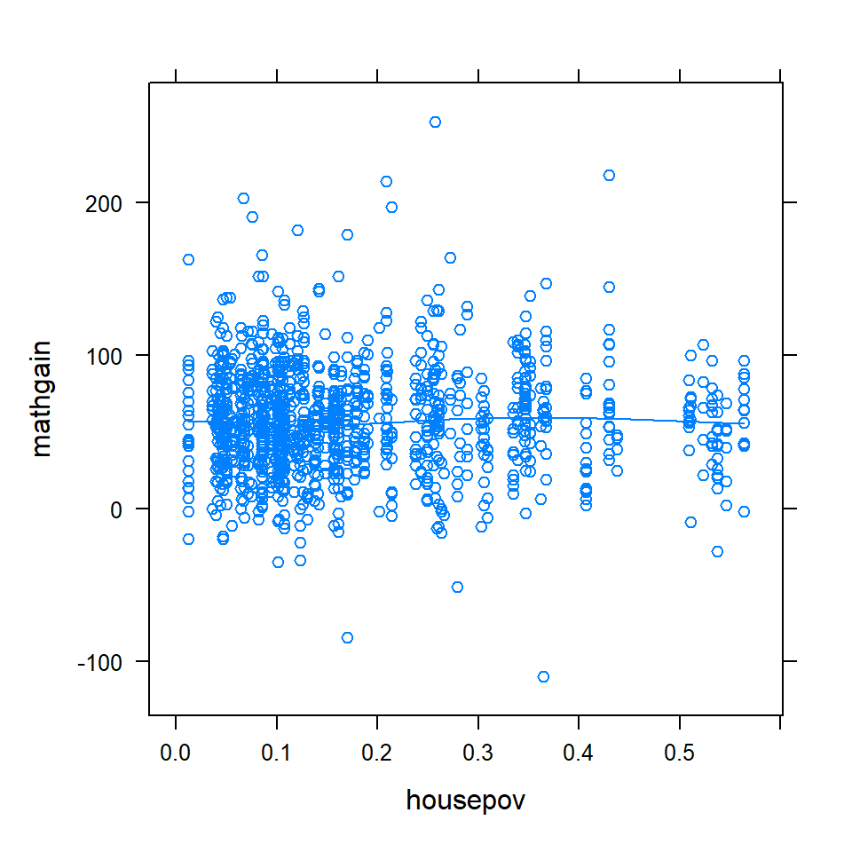

```r
xyplot(mathgain ~ housepov,
       SIIdata, # Fig. 3.10b
       type = c("p", "smooth"))
```

```r
detach(package:lattice)
```

- considerable variability of the observed values of the gain in the math achievement score even between the classes belonging to the same school.
- note that the interpretation of the plot is much enhanced by the labels provided on the horizontal axis
- Fig. 3.10b indicates the lack of a relationship between the observed values of the gain in the math achievement score for individual pupils and the values of the variable housepov.

## 3.5 FCAT Study: Target Score

```r
## (a) Summarizing scores for each child and attainment target
data(fcat, package = "nlmeU")
(scM <- with(fcat, tapply(scorec, list(id, target), mean)))
```

```
##     T1(4) T2(6) T3(8) T4(5) T5(9) T6(6) T7(8) T8(6) T9(5)
## 1       4     6     4     1     7     6     6     5     5
## 2       3     4     6     2     7     4     6     3     3
## 3       3     5     7     4     7     4     6     4     4
## 4       3     6     6     1     5     6     8     5     4
## 5       4     6     5     4     7     4     6     4     3
## 6       3     6     5     3     8     4     4     3     4
## 7       2     6     6     3     8     4     4     3     5
## 8       3     5     6     3     6     4     7     5     4
## 9       4     6     8     3     4     4     5     4     5
## 10      0     3     5     2     4     3     4     3     4
## 11      1     3     3     1     2     4     4     2     4
## 12      2     6     7     4     9     5     7     3     4
## 13      4     6     8     3     9     5     7     5     4
## 14      3     4     8     3     7     5     6     3     4
```

[output cut: 525 more lines]

```r
dim(fcat)
```

```
## [1] 4851    3
```

```r
dim(scM)
```

```
## [1] 539   9
```

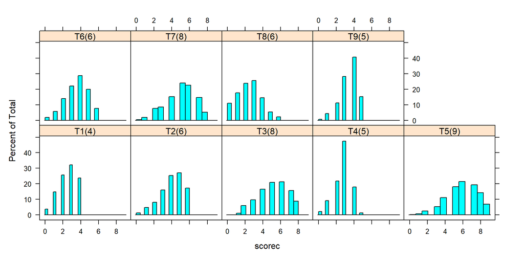

```r
## (b) Histograms of scores for different attainment targets
library(lattice)
histogram(~scorec | target, data = fcat, # Fig. 3.11
breaks = NULL)
```

```r
detach(package:lattice)
```

- `scM` is a tabulation of individual scores for all children.
- The Histograms clearly illustrate the differences in the measurement scale for different targets, which result from the varying number of items per target. Some asymmetry of the distribution of the scores can also be observed.